# Question

### What about Herbivore products is resonating with consumers and has this changed over time?

I will use topic modeling for Herbivore alone for a subset of Herbivore's products that were given a rating of 5 by the consumer. I've chosen this subset of data because if something about the products is **resonating with the consumers**, then it must mean that the consumers are happy with the products or that they love/like something about those products - therefore the consumers are most likely to give very high ratings to these products.

```python
import pandas as pd
import seaborn as sns
import matplotlib.pyplot as plt
import numpy as np
from nltk.corpus import stopwords
from nltk.stem import WordNetLemmatizer
from sklearn.decomposition import LatentDirichletAllocation
import gensim, spacy, logging, warnings
from gensim.utils import lemmatize, simple_preprocess
from gensim import corpora, models
import pyLDAvis.gensim
pyLDAvis.enable_notebook()
import warnings
warnings.filterwarnings("ignore", category=DeprecationWarning)

%matplotlib inline

np.random.seed(42)
```

## Import the data

```python
reviews = pd.read_csv('../data/reviews.csv')
```

## Subset the data to only contain the brand Herbivore and ratings of 5

```python
reviews_5 = reviews[(reviews['rating']==5) & (reviews['brand']=='Herbivore')]
reviews_5.shape
```

```
(504, 15)
```

## Combine the reivews columns and the title columns together into one column

Generally I would look at the titles separately from the reviews, however, in this dataset the titles were not so informative besides making the sentiment of the review apparent with common phrases like 'love this product', 'awesome buy' etc.. This is why I will combine the title with the review itself into a new column called **review_text**

```python
# merge review and title columns together
reviews_5['review_text'] = [''.join(i) for i in zip(reviews_5["title"].map(str),reviews_5["review"])]

# drop original review and title columns
reviews_5.drop(columns = ['title', 'review'], inplace = True)
```

## Define Stop Words

```python
from nltk.corpus import stopwords
stop_words = stopwords.words('english')
stop_words.extend(['from', 'subject', 're', 'edu', 'use', 'not', 'would', 'say', 'could', '_', 'be', 'know', 'good', 'go', 'get', 'do', 'done', 'try', 'many', 'some', 'nice', 'thank', 'think', 'see', 'rather', 'easy', 'easily', 'lot', 'lack', 'make', 'want', 'seem', 'run', 'need', 'even', 'right', 'line', 'even', 'also', 'may', 'take', 'come', 'im','ive','dont','hes','got', 'wa', 'ha', 'amazing', 'love', 'like', 'wonderful', 'great', 'really', 'very', 'obsessed', 'ever', 'every', 'never', 'awesome', 'super', 'makes', 'feels', 'good', 'absolutely', 'especially', 'honestly', 'specifically', 'generally', 'definitely','i', 'me', 'my', 'myself', 'we', 'our', 'ours', 'ourselves', 'you', "you're", "you've", "you'll", "you'd", 'your', 'yours', 'yourself', 'yourselves', 'he', 'him', 'his', 'himself', 'she', "she's", 'her', 'hers', 'herself', 'it', "it's", 'its', 'itself', 'they', 'them', 'their', 'theirs', 'themselves', 'what', 'which', 'who', 'whom', 'this', 'that', "that'll", 'these', 'those', 'am', 'is', 'are', 'was', 'were', 'be', 'been', 'being', 'have', 'has', 'had', 'having', 'do', 'does', 'did', 'doing', 'a', 'an', 'the', 'and', 'but', 'if', 'or', 'because', 'as', 'until', 'while', 'of', 'at', 'by', 'for', 'with', 'about', 'against', 'between', 'into', 'through', 'during', 'before', 'after', 'above', 'below', 'to', 'from', 'up', 'down', 'in', 'out', 'on', 'off', 'over', 'under', 'again', 'further', 'then', 'once', 'here', 'there', 'when', 'where', 'why', 'how', 'all', 'any', 'both', 'each', 'few', 'more', 'most', 'other', 'some', 'such', 'no', 'nor', 'not', 'only', 'own', 'same', 'so', 'than', 'too', 'very', 's', 't', 'can', 'will', 'just', 'don', "don't", 'should', "should've", 'now', 'd', 'll', 'm', 'o', 're', 've', 'y', 'ain', 'aren', "aren't", 'couldn', "couldn't", 'didn', "didn't", 'doesn', "doesn't", 'hadn', "hadn't", 'hasn', "hasn't", 'haven', "haven't", 'isn', "isn't", 'ma', 'mightn', "mightn't", 'mustn', "mustn't", 'needn', "needn't", 'shan', "shan't", 'shouldn', "shouldn't", 'wasn', "wasn't", 'weren', "weren't", 'won', "won't", 'wouldn', "wouldn't", 'from', 'subject', 're', 'edu', 'use', 'not', 'would', 'say', 'could', '_', 'be', 'know', 'good', 'go', 'get', 'do', 'done', 'try', 'many', 'some', 'nice', 'thank', 'think', 'see', 'rather', 'easy', 'easily', 'lot', 'lack', 'make', 'want', 'seem', 'run', 'need', 'even', 'right', 'line', 'even', 'also', 'may', 'take', 'come', 'im', 'ive', 'dont', 'hes', 'got', 'wa', 'ha', 'amazing', 'love', 'like', 'wonderful', 'great', 'really', 'very', 'obsessed', 'ever', 'every', 'never', 'awesome', 'super', 'makes', 'feels', 'good', 'from', 'subject', 're', 'edu', 'use', 'not', 'would', 'say', 'could', '_', 'be', 'know', 'good', 'go', 'get', 'do', 'done', 'try', 'many', 'some', 'nice', 'thank', 'think', 'see', 'rather', 'easy', 'easily', 'lot', 'lack', 'make', 'want', 'seem', 'run', 'need', 'even', 'right', 'line', 'even', 'also', 'may', 'take', 'come', 'im', 'ive', 'dont', 'hes', 'got', 'wa', 'ha', 'amazing', 'love', 'like', 'wonderful', 'great', 'really', 'very', 'obsessed', 'ever', 'every', 'never', 'awesome', 'super', 'makes', 'feels', 'good', 'from', 'subject', 're', 'edu', 'use', 'not', 'would', 'say', 'could', '_', 'be', 'know', 'good', 'go', 'get', 'do', 'done', 'try', 'many', 'some', 'nice', 'thank', 'think', 'see', 'rather', 'easy', 'easily', 'lot', 'lack', 'make', 'want', 'seem', 'run', 'need', 'even', 'right', 'line', 'even', 'also', 'may', 'take', 'come', 'im', 'ive', 'dont', 'hes', 'got', 'wa', 'ha', 'amazing', 'love', 'like', 'wonderful', 'great', 'really', 'very', 'obsessed', 'ever', 'every', 'never', 'awesome', 'super', 'makes', 'feels', 'good', 'definitely', 'especially', 'honestly'])

stop_words = list(set(stop_words))
```

## Preprocess the reviews data

Generally, when I reuse lengthy functions in various notebooks, I throw them in a class object and save that in a pickle file, then import the class like any other python library and use the methods within it. This is something I would eventually spend time doing to further automate my data science workflow. However, to focus on insights with my time, rather than automation, I'm skipping this part. Apologies for repating the lengthy functions two notebooks in a row.

```python
# Build bigram and trigram models   # WARNING: TAKES ABOUT 40 MINS TO RUN 2aq

bigram = gensim.models.Phrases(reviews_5['review_text'], min_count=5, threshold=100) # higher threshold fewer phrases.
trigram = gensim.models.Phrases(bigram[reviews_5['review_text']], threshold=100)
bigram_mod = gensim.models.phrases.Phraser(bigram)
trigram_mod = gensim.models.phrases.Phraser(trigram)
```

```python
# This function preprocesses text data

def process_words(texts, stop_words=stop_words, allowed_postags=['NOUN', 'ADJ', 'VERB', 'ADV']):
    """Remove stopwords, form Bigrams, trigrams and lemmatization"""
    texts = [[word for word in simple_preprocess(str(doc)) if word not in stop_words] for doc in texts]
    texts = [bigram_mod[doc] for doc in texts]
    texts = [trigram_mod[bigram_mod[doc]] for doc in texts]
    texts_out = []
    nlp = spacy.load('en', disable=['parser', 'ner'])
    for sent in texts:
        doc = nlp(" ".join(sent))
        texts_out.append([token.lemma_ for token in doc if token.pos_ in allowed_postags])
    # remove stopwords once more after lemmatization
    texts_out = [[word for word in simple_preprocess(str(doc)) if word not in stop_words] for doc in texts_out]
    return texts_out

data_ready = process_words(reviews_5['review_text'])  # processed Text Data!
```

## Build a Latent Dirichlet Allocation Model (LDA) and view the topics

```python
# Create Dictionary
id2word = corpora.Dictionary(data_ready)

# Create Corpus: Term Document Frequency
corpus = [id2word.doc2bow(text) for text in data_ready]

# Build LDA model
lda_model = gensim.models.ldamodel.LdaModel(corpus=corpus,
                                           id2word=id2word,
                                           num_topics=4,
                                           random_state=100,
                                           update_every=1,
                                           chunksize=20,
                                           passes=20,
                                           alpha='symmetric',
                                           iterations=100,
                                           per_word_topics=True)
lda_model.print_topics()
```

```
[(0,
  '0.064*"skin" + 0.027*"mask" + 0.020*"herbivore" + 0.016*"look" + 0.014*"soft" + 0.014*"first" + 0.014*"smell" + 0.013*"give" + 0.012*"texture" + 0.011*"glow"'),
 (1,
  '0.034*"pink" + 0.033*"spray" + 0.033*"smell" + 0.031*"cloud" + 0.024*"hair" + 0.017*"salt" + 0.012*"excellent" + 0.011*"nourishing" + 0.009*"jasmine" + 0.009*"hydrate"'),
 (2,
  '0.061*"skin" + 0.053*"oil" + 0.017*"dry" + 0.017*"acne" + 0.017*"face" + 0.016*"moisturizer" + 0.013*"scent" + 0.012*"night" + 0.011*"well" + 0.011*"phoenix"'),
 (3,
  '0.040*"set" + 0.035*"day" + 0.022*"purchase" + 0.019*"bath" + 0.018*"size" + 0.013*"makeup" + 0.012*"already" + 0.012*"better" + 0.011*"everything" + 0.011*"smell"')]
```

## Create a dataframe with topic related features

```python
def format_topics_sentences(ldamodel=None, corpus=corpus, texts='Herbivore'):
    # Init output
    sent_topics_df = pd.DataFrame()

    # Get main topic in each document
    for i, row_list in enumerate(ldamodel[corpus]):
        row = row_list[0] if ldamodel.per_word_topics else row_list
        # print(row)
        row = sorted(row, key=lambda x: (x[1]), reverse=True)
        # Get the Dominant topic, Perc Contribution and Keywords for each document
        for j, (topic_num, prop_topic) in enumerate(row):
            if j == 0:  # => dominant topic
                wp = ldamodel.show_topic(topic_num)
                topic_keywords = ", ".join([word for word, prop in wp])
                sent_topics_df = sent_topics_df.append(pd.Series([int(topic_num), round(prop_topic,4), topic_keywords]), ignore_index=True)
            else:
                break
    sent_topics_df.columns = ['Dominant_Topic', 'Perc_Contribution', 'Topic_Keywords']

    # Add original text to the end of the output
    contents = pd.Series(texts)
    sent_topics_df = pd.concat([sent_topics_df, contents], axis=1)
    return(sent_topics_df)


df_topic_sents_keywords = format_topics_sentences(ldamodel=lda_model, corpus=corpus, texts=data_ready)

# Format
df_dominant_topic = df_topic_sents_keywords.reset_index()
df_dominant_topic.columns = ['Document_No', 'Dominant_Topic', 'Topic_Perc_Contrib', 'Keywords', 'Text']
df_dominant_topic.head(10)
```

|  | Document_No | Dominant_Topic | Topic_Perc_Contrib | Keywords | Text |
| --- | --- | --- | --- | --- | --- |
| 0 | 0 | 2.0 | 0.9703 | skin, oil, dry, acne, face, moisturizer, scent, night, well, phoenix | [calm, lightweight, facial, oil, facial, oil, skin, sensitive, combination, redness, cheek, herb... |
| 1 | 1 | 2.0 | 0.5578 | skin, oil, dry, acne, face, moisturizer, scent, night, well, phoenix | [miracle, producti, sensitive, dry, acne, prone, skin, problem, buy, intensive, hydration, cream... |
| 2 | 2 | 1.0 | 0.5449 | pink, spray, smell, cloud, hair, salt, excellent, nourishing, jasmine, hydrate | [amazingsmell, back, lotion] |
| 3 | 3 | 2.0 | 0.9493 | skin, oil, dry, acne, face, moisturizer, scent, night, well, phoenix | [forget, moisturizerif, break, oily, skin, oil, regular, moisturizer, oil, oil, well, time, lapi... |
| 4 | 4 | 0.0 | 0.7688 | skin, mask, herbivore, look, soft, first, smell, give, texture, glow | [lovelythis, oil, smell, ingredient, list, short, mix, lotion, long, way, indulgent, packaging, ... |
| 5 | 5 | 2.0 | 0.8269 | skin, oil, dry, acne, face, moisturizer, scent, night, well, phoenix | [lovelet, serious, face, mist, lip, balm, obsession, collection, border, ridiculous, spray, mois... |
| 6 | 6 | 3.0 | 0.6336 | set, day, purchase, bath, size, makeup, already, better, everything, smell | [heaveni, facial, oil, much, buy, traveler, size, herbivore, directly, beautiful, smell, luxurio... |
| 7 | 7 | 1.0 | 0.6181 | pink, spray, smell, cloud, hair, salt, excellent, nourishing, jasmine, hydrate | [excellent, hydration, oilyi, jasmine, smell, overpower, spray, oil, quickly, absorb, skin] |
| 8 | 8 | 0.0 | 0.8427 | skin, mask, herbivore, look, soft, first, smell, give, texture, glow | [lovethis, stuff, skin, soft, smooth, dry, skin, cleansing, clarisonic, change, skin, texture, s... |
| 9 | 9 | 0.0 | 0.9369 | skin, mask, herbivore, look, soft, first, smell, give, texture, glow | [amazingthis, beautifully, package, effective, expect, gritty, exfoliation, mix, well, spread, t... |

```python
# Display setting to show more characters in column
pd.options.display.max_colwidth = 100

sent_topics_sorteddf_mallet = pd.DataFrame()
sent_topics_outdf_grpd = df_topic_sents_keywords.groupby('Dominant_Topic')

for i, grp in sent_topics_outdf_grpd:
    sent_topics_sorteddf_mallet = pd.concat([sent_topics_sorteddf_mallet,
                                             grp.sort_values(['Perc_Contribution'], ascending=False)],
                                            axis=0)

# Reset Index
sent_topics_sorteddf_mallet.reset_index(drop=True, inplace=True)

# Format
sent_topics_sorteddf_mallet.columns = ['Topic_Num', "Topic_Perc_Contrib", "Keywords", "Representative Text"]

# Show
sent_topics_sorteddf_mallet.head()
```

|  | Topic_Num | Topic_Perc_Contrib | Keywords | Representative Text |
| --- | --- | --- | --- | --- |
| 0 | 0.0 | 0.9747 | skin, mask, herbivore, look, soft, first, smell, give, texture, glow | [new, favorite, hard, transition, natural, skin, care, face, mask, favorite, self, care, method,... |
| 1 | 0.0 | 0.9708 | skin, mask, herbivore, look, soft, first, smell, give, texture, glow | [mask, mask, slight, tingly, feel, refresh, harsh, korre, brighten, peel, much, well, smell, lea... |
| 2 | 0.0 | 0.9667 | skin, mask, herbivore, look, soft, first, smell, give, texture, glow | [silky, soft, slightly, herbivore, one, blue, tansy, mask, feel, skin, control, break, corner, g... |
| 3 | 0.0 | 0.9623 | skin, mask, herbivore, look, soft, first, smell, give, texture, glow | [favorite, mask, find, new, favorite, mask, put, end, leave, hour, fall, asleep, skin, tone, smo... |
| 4 | 0.0 | 0.9453 | skin, mask, herbivore, look, soft, first, smell, give, texture, glow | [loovveee, stuff, smell, package, aesthetically, pleasing, leave, skin, feel, silky, smooth, nex... |

## Plot a wordcloud of the most dominant words in each topic for Herbivore's products with 5-star ratings (what consumers love)

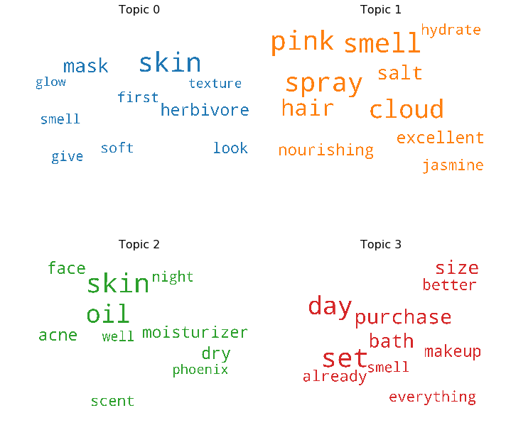

```python
# 1. Wordcloud of Top N words in each topic
from matplotlib import pyplot as plt
from wordcloud import WordCloud, STOPWORDS
import matplotlib.colors as mcolors

cols = [color for name, color in mcolors.TABLEAU_COLORS.items()]  # more colors: 'mcolors.XKCD_COLORS'

cloud = WordCloud(stopwords=stop_words,
                  background_color='white',
                  width=2500,
                  height=1800,
                  max_words=20,
                  colormap='tab10',
                  color_func=lambda *args, **kwargs: cols[i],
                  prefer_horizontal=1.0)

topics = lda_model.show_topics(formatted=False)

fig, axes = plt.subplots(2, 2, figsize=(10,10), sharex=True, sharey=True)

for i, ax in enumerate(axes.flatten()):
    fig.add_subplot(ax)
    topic_words = dict(topics[i][1])
    cloud.generate_from_frequencies(topic_words, max_font_size=300)
    plt.gca().imshow(cloud)
    plt.gca().set_title('Topic ' + str(i), fontdict=dict(size=16))
    plt.gca().axis('off')


plt.subplots_adjust(wspace=0, hspace=0)
plt.axis('off')
plt.margins(x=0, y=0)
plt.tight_layout()
plt.show()
```

```python
# Get topic weights and dominant topics ------------
from sklearn.manifold import TSNE
from bokeh.plotting import figure, output_file, show
from bokeh.models import Label
from bokeh.io import output_notebook

# get topic weights
topic_weights = []
for i, row_list in enumerate(lda_model[corpus]):
    topic_weights.append([w for i, w in row_list[0]])

# array of topic weights
arr = pd.DataFrame(topic_weights).fillna(0).values

# keep the well separated points (optional)
arr = arr[np.amax(arr, axis=1) > 0.35]

# dominant topic number in each doc
topic_num = np.argmax(arr, axis=1)

# tSNE dimension reduction
tsne_model = TSNE(n_components=2, verbose=1, random_state=0, angle=.99, init='pca')
tsne_lda = tsne_model.fit_transform(arr)



# plot the topic clusters using Bokeh
output_notebook()
n_topics = 5
mycolors = np.array([color for name, color in mcolors.TABLEAU_COLORS.items()])
plot = figure(title="t-SNE Clustering of {} LDA Topics".format(n_topics),
              plot_width=900, plot_height=700)
plot.scatter(x=tsne_lda[:,0], y=tsne_lda[:,1], color=mycolors[topic_num])
show(plot)
```

```
[t-SNE] Computing 91 nearest neighbors...
[t-SNE] Indexed 502 samples in 0.000s...
[t-SNE] Computed neighbors for 502 samples in 0.011s...
[t-SNE] Computed conditional probabilities for sample 502 / 502
[t-SNE] Mean sigma: 0.106479
[t-SNE] KL divergence after 250 iterations with early exaggeration: 59.391582
[t-SNE] KL divergence after 1000 iterations: 0.404252
```

[interactive chart not shown]

## Interactive visualization to show separation and importance (size) of topics and the distribution of most dominant words in those topics.

```python
import pyLDAvis.gensim
pyLDAvis.enable_notebook()
vis = pyLDAvis.gensim.prepare(lda_model, corpus, dictionary=lda_model.id2word)
vis
```

[interactive chart not shown]

# 2. Analyses of Consumer Interction With Herbivore Over Time

## Import herbivore data and set the date column to index as a datetime object

```python
herbivore = pd.read_csv('herbivore.csv')
# convert review_date values to datetime objects
herbivore['date'] = pd.to_datetime(herbivore['date'])
herbivore.dtypes

# set the date column to index and sort it
herbivore.set_index('date', inplace=True)
herbivore.sort_index(inplace=True)
```

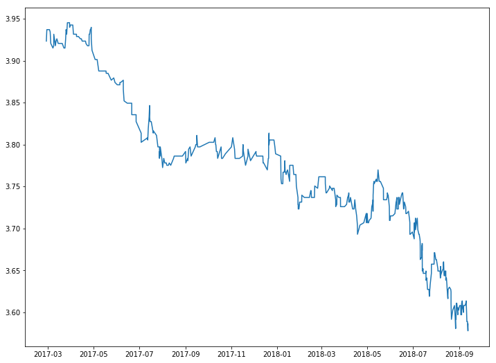

```python
plt.figure(figsize=(12,9))
plt.plot(herbivore['rating'].rolling(365).mean())
```

The upvotes/downvotes are the **consumer_vote_counts** feature engineered in Notebook 1. This feature represents the sum of the helpful and unhlepful review votes - the number of consumers who read a review and clicked 'helpful' or 'unhelpful' on it

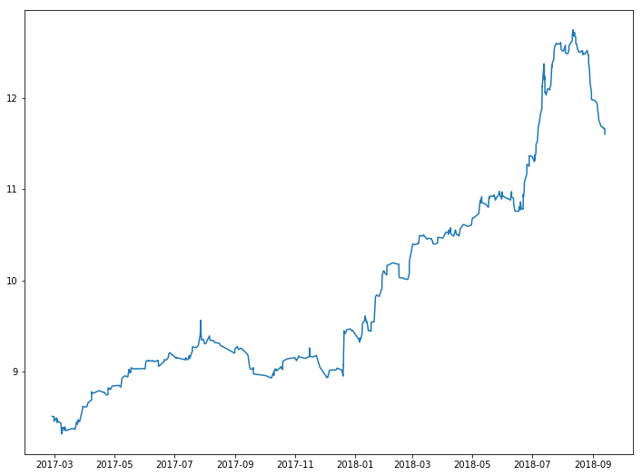

```python
plt.figure(figsize=(12,9))
plt.plot(herbivore['consumer_vote_counts'].rolling(365).mean())
```

## Plot the volume of reviews (review counts) by month over time

```python
# convert the integers in month column to strings with a leading zero for single digit months

herbivore['month'].replace({1:'01', 2:'02', 3:'03', 4:'04', 5:'05', 6:'06', 7:'07', 8:'08', 9:'09'}, inplace = True)
herbivore['month'].dtypes
```

```
dtype('O')
```

```python
# merge the year and the month columns together into a month_year year column. This will be the x-axis for plotting the review columnes over time

herbivore['month_year']= ['_'.join(i) for i in zip(herbivore['month'].astype(str), herbivore['year'].astype(str))]
```

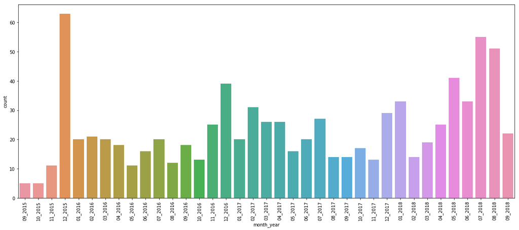

```python
# plot the review volumes over time (order parameter set to preserve the specified order. Otherwise seaborn reorders the x-variable)

plt.figure(figsize=(20,8))
ax = sns.countplot(x="month_year", data=herbivore, order = ['09_2015', '10_2015', '11_2015', '12_2015','01_2016', '02_2016', '03_2016', '04_2016', '05_2016', '06_2016', '07_2016', '08_2016','09_2016', '10_2016', '11_2016', '12_2016', '01_2017', '02_2017', '03_2017', '04_2017', '05_2017', '06_2017', '07_2017', '08_2017','09_2017', '10_2017', '11_2017', '12_2017', '01_2018', '02_2018', '03_2018', '04_2018', '05_2018', '06_2018', '07_2018', '08_2018','09_2018'])
plt.xticks(rotation = 'vertical');
```

Something interesting is happening here.

**OBSERVATION 1** There is some **seasonality** apparent here: generally, the review volumes spike up every year around the major winter holiday season (month 12). More minor spikes are also noticable in mid-summer months (month 7). Unfortunately this data is not ample enough to conclude with certainty that there is in fact seasonality in review volumes, but it's a good starting point to invstigate further. If I had more time, I would make this same plot for some other longer established brand which has a lot more data and then repeat the process for a few other brands to see if the same pattern arises. But due to time constraints I'll skip testing this to confirm the seasonality pattern.

**Assumptions regarding observation 1** Let's assume that this observed pattern is in fact seasonality in the data. The pattern would indicate the volume of reviews goes up around winter holiday season and midsummer. Another assumption I'm making here is that there must be some positive correlation between volume of sales and the volume of reviews consumers posts. This correlation might be weak, but I presume it would nevertheless be there. It's expected that sales would go up around winter holiday season given that consumers are shopping for gifts for their friends and family. It's also expected that, especially in the beauty products industry, sales would go up around mid summer months too - because of the warmer whether and a correlation that exhists between summer season and vacationing, trips to the beach, bikini season, etc. Summer is probably one of the more profit generating seasons for beauty-product retailers with increased sales not just due to vacation season but also due to increased media marketing on the necessity of sunscreens, self-tanners, beach wavy hair sprays, bright colored makeup trends, etc...So then, if the seasonality ovserved here in review volumes can be explained by expected seasonality in sales, then we may conclude that the **volume of reviews might be a reasonably good proxy variable for sales**. In the absence of sales data, then we might be able to use review volume to gain insights about the overall performance of the brand.

**OBSERVATION 2** **There is an anomalously large looking spike in the volume of reviews in month 12, 2015**. Conclusions cannot be made without further information as to why the review volume spiked up so high during this year, but here are a couple of things I assume might be a reasonable cause for this:

1. The data for Herbivore brand starts a few months before this anomalous spike. Maybe there was no data before this date because it's around this date that the brand was launched. If that's the case, the spike about the brand's first holiday season might be explained by the brand's deliberate grand-opening marketing and promotional efforts. Further research is needed to confirm or refute this assumption.
2. The spike might be due to a time where a major beauty product retailer such as Sephora picked up the brand and launched a marketing campaign for it in their stores. Given that the data we're dealing with here comes from Sephora, I would assume this is more likely than point 1 stated above. Sephora might have picked up Herbivore at around month 9, 2015 which is why we might have our data starting at that time. Then Sephora may have taken a couple of months to plan and implement a marketing strategy for the brand, much like they do for all new brands they acquire and carry in their stores or when they wish to refresh the consumer's awareness of a brand that has been going a bit stale at their stores. If this is true, then that would also be potential cause for the spike in review volumes around this time. Again, without further research I cannot confirm this assumption.

**OBSERVATION 3** **The longer term trend of review volumes seems to be growing** slowly and weakly, but growing nevertheless. What's most interesting is the faster growth in review volumes in 2018. The mid-summer spike seems significantly larger than in previous years, and if the pattenr were to continue throuugh month 12 2018, we would expect to see a much larger spike in the winter holiday season too (this is speculative extrapolation of the data). Overall, it looks like consumer engagement via review counts (and perhaps sales) were growing more quickly in 2018 than they did in the previous years. Either something changed in 2018 (perhaps CircleUp partnered with the brand??) or the effects of consumers becoming more familiar with the brand over time are really starting to kick-in here. In any case, the brand's overall performance seems to be improving over time.

## A look at Herbivore's consumer engagement through reviews over the years

```python
herbivore.groupby('year')['reviewer'].count()
```

```
year
2015     84
2016    233
2017    253
2018    293
Name: reviewer, dtype: int64
```

Create sets of consumers for each year

```python
# create a list of consumers in 2015

consumers_15 = []

for i in herbivore['2015']['reviewer']:
    consumers_15.append(i)
consumers_15 = set(consumers_15)


# create a list of consumers in 2016
consumers_16 = []

for i in herbivore['2016']['reviewer']:
    consumers_16.append(i)
consumers_16 = set(consumers_16)

# create a list of consumers in 2017
consumers_17 = []

for i in herbivore['2017']['reviewer']:
    consumers_17.append(i)
consumers_17 = set(consumers_17)


# create a list of consumers in 2018
consumers_18 = []

for i in herbivore['2018']['reviewer']:
    consumers_18.append(i)
consumers_18 = set(consumers_18)
```

## Look at the intersection of consumer sets from year to year

This would ideally approximate consumer retention, however, it looks like an entire year is too long of a period to more reliably measure consumer retention (measured by reviews these consumers leave).

```python
consumers_15.intersection(consumers_16)
```

```
{'0', 'kas24', 'wren10'}
```

```python
consumers_16.intersection(consumers_17)
```

```
{'0', 'jonahfide', 'princeofcats'}
```

```python
consumers_17.intersection(consumers_18)
```

```
{'0', 'Jacquel0701', 'beautymama21', 'nataliinnaa'}
```

```python
consumers_16.intersection(consumers_18)
```

```
{'0', 'LexiiiiK', 'hcguy', 'sarahshter'}
```

```python
consumers_15.intersection(consumers_17)
```

```
{'0', 'excellentresults'}
```

The data above is too few to make any conclusions.

Next step to follow up on this would be to get a sense of percentages of retained customers vs newly acquired customers vs lost customers over a period of 90 days. Perhaps this smaller time period would be a better interval to get a sense of customer churn.

**NOTE**: Consumer retention/acquisition analyses using only data of consumers who leave reviews is not sufficient. I would need more data to make any solid conclusions. Th data needed for this is subscription counts, consumer account/profile counts with Herbivore itself, the frequency and duration over which the consumer engages with the brand, etc. However, just like we may be able to use review volumes as a proxy for sales, we may also be able to use the consumer data based on reviews as a proxy for some insights about consumer acquisiton/retention of the brand.

I'd also be extremely happy to work with data on consumer basket sizes in addition to churn rates. This would allow me to identify the most influencial customers - the ones generating the most profit for the brand and I would leverage this information along with forecasts of these customers leaving to strategically target them in advertising campaigns for the purpose of retaining their loyalty to the brand for a longer term.

# 3. Explorations on Herbivore Product Performance Over Time

```python
# get the number of distinct Herbivore products
len(set(herbivore['product']))
```

```
24
```

```python
# create dataframes with year column, average product rating and product id for each year

products_2015 = pd.DataFrame(herbivore['2015'].groupby('product')['rating'].mean().sort_values(ascending = False)).reset_index()
products_2015['year'] = 2015

products_2016 = pd.DataFrame(herbivore['2016'].groupby('product')['rating'].mean().sort_values(ascending = False)).reset_index()
products_2016['year']=2016

products_2017 = pd.DataFrame(herbivore['2017'].groupby('product')['rating'].mean().sort_values(ascending = False)).reset_index()
products_2017['year']=2017

products_2018 = pd.DataFrame(herbivore['2018'].groupby('product')['rating'].mean().sort_values(ascending = False)).reset_index()
products_2018['year']=2018
```

```python
# concatenate the above dataframes vertically

products_over_time = pd.concat([products_2015, products_2016], axis = 0)
products_over_time = pd.concat([products_over_time, products_2017], axis = 0)
products_over_time = pd.concat([products_over_time, products_2018], axis = 0)
```

```python
# check to make sure there are no 0 ratings (these indicators that no raiting was given)

products_over_time[products_over_time['rating']==0]
```

|  | product | rating | year |
| --- | --- | --- | --- |

```python
products_over_time.rename(columns = {'rating':'avg_rating'}, inplace = True)
products_over_time.head()
```

|  | product | avg_rating | year |
| --- | --- | --- | --- |
| 0 | P400200 | 5.000000 | 2015 |
| 1 | P400206 | 4.923077 | 2015 |
| 2 | P400201 | 4.833333 | 2015 |
| 3 | P400202 | 4.416667 | 2015 |
| 4 | P400204 | 4.166667 | 2015 |

```python
# print the set of distinct products

print(set(products_over_time['product']))
```

```
{'P400211', 'P400199', 'P410829', 'P431839', 'P400206', 'P407444', 'P415745', 'P432655', 'P400203', 'P427626', 'P400210', 'P400204', 'P421600', 'P400202', 'P432662', 'P433642', 'P400209', 'P424368', 'P400200', 'P430822', 'P400205', 'P400207', 'P400201', 'P431840'}
```

There are some patterns in the product IDs. The code types maybe mean to represent different types of products (for example: hair product vs skincare product). This can be looked into in more depth by reading some sample reviews about the products that come from a simingly distinct group of codes. The most predominant group of products has a code that starts with P400. I will use the set of these products separately from the rest of the products to generate two plots. I basically want to split up the number of products to include in a single plot to avoid clutter. And instead of randomly choosing how to split the products, I'm splitting them on what appears to be a distinguishing characteristic in the product id that may be of informative value to Herbivore at least.

```python
# sort products from smallest to largest (in number that appears after the letter p) and reset the index of dataframe
products_over_time = products_over_time.sort_values(by = 'product', ascending = True).reset_index()
```

```python
# subset the new dataframe by the new index and save two different dataframes for products of group p400 and products of all other groups
p400 = products_over_time.iloc[0:46]
p_others = products_over_time.iloc[46:]
```

## Plot the average rating of a product over time (group p400 products)

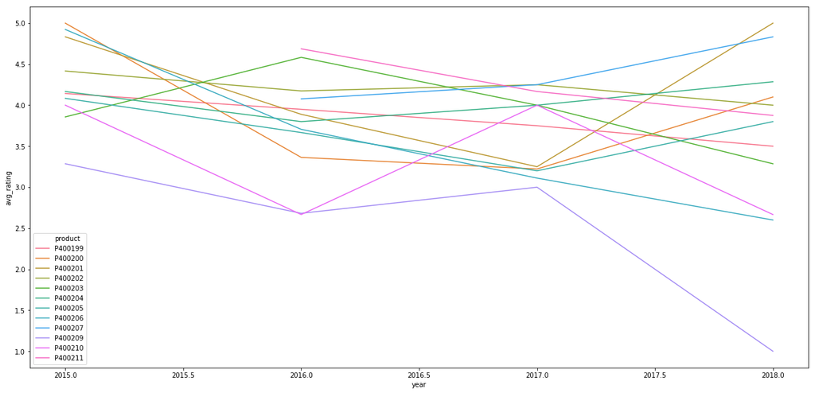

```python
plt.figure(figsize=(21,10))
ax = sns.lineplot(x="year", y='avg_rating', hue= 'product',
                  data=p400)
```

## Plot the average rating of a product over time (group of all other products)

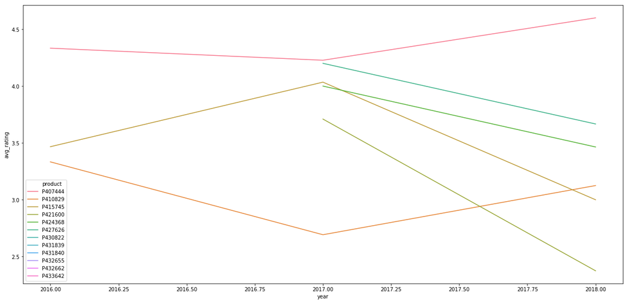

```python
plt.figure(figsize=(21,10))
ax = sns.lineplot(x="year", y="avg_rating", hue= 'product',
                  data=p_others)
```

```python
# get product average ratings sorted by rating from highest to lowest
herbivore.groupby('product')['rating'].mean().sort_values(ascending = False)
```

```
product
P407444    4.311111
P400211    4.309524
P400207    4.279070
P400202    4.222222
P400201    4.038462
P400204    4.027778
P400203    4.022727
P431840    3.923077
P400199    3.866667
P427626    3.833333
P400206    3.818182
P400205    3.755556
P415745    3.755102
P433642    3.675000
P424368    3.651163
P400200    3.547619
P431839    3.500000
P421600    3.435897
P432662    3.384615
P432655    3.372093
P430822    3.230769
P400210    3.200000
P410829    3.026316
P400209    2.883721
Name: rating, dtype: float64
```

While this plot is giving me an overall idea of different product performances over time, it would make more sense to take the **weighted** average of ratings for these products over time, as opposed to just the mean. This is because I'd want to account for the actual number of reviews per year that generate the ratings in my calculations.

Some ideas for next steps include applying topic model to get consumers narrative about these products over the years to udnerstand why the performance of some products declines, while the others remains high or increases over time.